# Predicting Diamonds Price - Linear Regression Example

Piotr Wieczorek

2023-10-20

```r
rm(list=ls())
```

## Libraries

```r
library(tidyverse)
library(scales)
library(glue)
library(skimr)
library(tableone)
library(janitor)
library(caret)
library(fastDummies)
```

## Reading and exploring the data

```r
df <- diamonds
```

### Overall summary

```r
summary(df)
```

```
##      carat               cut        color        clarity          depth
##  Min.   :0.2000   Fair     : 1610   D: 6775   SI1    :13065   Min.   :43.00
##  1st Qu.:0.4000   Good     : 4906   E: 9797   VS2    :12258   1st Qu.:61.00
##  Median :0.7000   Very Good:12082   F: 9542   SI2    : 9194   Median :61.80
##  Mean   :0.7979   Premium  :13791   G:11292   VS1    : 8171   Mean   :61.75
##  3rd Qu.:1.0400   Ideal    :21551   H: 8304   VVS2   : 5066   3rd Qu.:62.50
##  Max.   :5.0100                     I: 5422   VVS1   : 3655   Max.   :79.00
##                                     J: 2808   (Other): 2531
##      table           price             x                y
##  Min.   :43.00   Min.   :  326   Min.   : 0.000   Min.   : 0.000
##  1st Qu.:56.00   1st Qu.:  950   1st Qu.: 4.710   1st Qu.: 4.720
##  Median :57.00   Median : 2401   Median : 5.700   Median : 5.710
##  Mean   :57.46   Mean   : 3933   Mean   : 5.731   Mean   : 5.735
##  3rd Qu.:59.00   3rd Qu.: 5324   3rd Qu.: 6.540   3rd Qu.: 6.540
##  Max.   :95.00   Max.   :18823   Max.   :10.740   Max.   :58.900
##
##        z
##  Min.   : 0.000
##  1st Qu.: 2.910
##  Median : 3.530
##  Mean   : 3.539
##  3rd Qu.: 4.040
##  Max.   :31.800
##
```

### Looking for NA values

```r
colSums(is.na(df))
```

```
##   carat     cut   color clarity   depth   table   price       x       y       z
##       0       0       0       0       0       0       0       0       0       0
```

```r
factor_colnames <- df %>%
  select_if(is.factor) %>%
  colnames()
```

```r
factor_colnames
```

```
## [1] "cut"     "color"   "clarity"
```

### Summary of factor variables

```r
tableone::CreateCatTable(data=df,vars=factor_colnames)
```

```
##
##                Overall
##   n            53940
##   cut (%)
##      Fair       1610 ( 3.0)
##      Good       4906 ( 9.1)
##      Very Good 12082 (22.4)
##      Premium   13791 (25.6)
##      Ideal     21551 (40.0)
##   color (%)
##      D          6775 (12.6)
##      E          9797 (18.2)
##      F          9542 (17.7)
##      G         11292 (20.9)
##      H          8304 (15.4)
##      I          5422 (10.1)
##      J          2808 ( 5.2)
##   clarity (%)
##      I1          741 ( 1.4)
##      SI2        9194 (17.0)
##      SI1       13065 (24.2)
##      VS2       12258 (22.7)
##      VS1        8171 (15.1)
##      VVS2       5066 ( 9.4)
##      VVS1       3655 ( 6.8)
##      IF         1790 ( 3.3)
```

### Aggregating least frequent categories

```r
df <- df %>%
  mutate(clarity = fct_collapse(clarity,
                                "Other_clarity" = c("I1","IF")),
         cut = fct_collapse(cut,
                            "Other_cut" = c("Fair","Good")))
```

### All numerical variable’s density plots

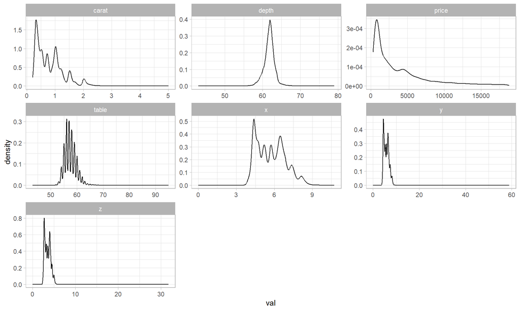

```r
df %>%
  select(c(1,5:10)) %>%
  gather(1:7,key="key",value="val") %>%
  ggplot(aes(x=val)) +
  geom_density() +
  facet_wrap(~key,scales="free") +
  theme_light()
```

### Taking the log out of price

```r
df[,c("price")] <- sapply(df[,c("price")], function(x) log(x))
```

```r
colnames(df)[7] <- "price_log"
```

```r
df %>%
  select_if(is.numeric) %>%
  head()
```

```
## # A tibble: 6 × 7
##   carat depth table price_log     x     y     z
##   <dbl> <dbl> <dbl>     <dbl> <dbl> <dbl> <dbl>
## 1  0.23  61.5    55      5.79  3.95  3.98  2.43
## 2  0.21  59.8    61      5.79  3.89  3.84  2.31
## 3  0.23  56.9    65      5.79  4.05  4.07  2.31
## 4  0.29  62.4    58      5.81  4.2   4.23  2.63
## 5  0.31  63.3    58      5.81  4.34  4.35  2.75
## 6  0.24  62.8    57      5.82  3.94  3.96  2.48
```

### Exploring correlation between numerical variables

```r
cor(df%>%select_if(is.numeric),method = "spearman")
```

```
##                carat       depth      table  price_log           x           y
## carat     1.00000000  0.03010375  0.1949803 0.96288280  0.99611660  0.99557175
## depth     0.03010375  1.00000000 -0.2450611 0.01001967 -0.02344221 -0.02542522
## table     0.19498032 -0.24506114  1.0000000 0.17178448  0.20223061  0.19573406
## price_log 0.96288280  0.01001967  0.1717845 1.00000000  0.96319611  0.96271882
## x         0.99611660 -0.02344221  0.2022306 0.96319611  1.00000000  0.99789493
## y         0.99557175 -0.02542522  0.1957341 0.96271882  0.99789493  1.00000000
## z         0.99318344  0.10349836  0.1598782 0.95723227  0.98735532  0.98706751
##                   z
## carat     0.9931834
## depth     0.1034984
## table     0.1598782
## price_log 0.9572323
## x         0.9873553
## y         0.9870675
## z         1.0000000
```

### Deleting variables based on the correlation matrix

```r
df<-df%>%
  select(-c("y","z"))
```

```r
cor(df%>%select_if(is.numeric))
```

```
##                carat         depth      table    price_log           x
## carat     1.00000000  0.0282243143  0.1816175 0.9202065980  0.97509423
## depth     0.02822431  1.0000000000 -0.2957785 0.0008601097 -0.02528925
## table     0.18161755 -0.2957785215  1.0000000 0.1582078941  0.19534428
## price_log 0.92020660  0.0008601097  0.1582079 1.0000000000  0.95800995
## x         0.97509423 -0.0252892470  0.1953443 0.9580099526  1.00000000
```

### Deleting outliers from the x variable

```r
x_outliers <- boxplot.stats(df$x)$out
x_outliers_ind <- which(df$x %in% c(x_outliers))
print(length(x_outliers)) # number of x outliers
```

```
## [1] 32
```

```r
df <- df[-x_outliers_ind,] %>%
  select(-c("table","depth","carat"))
```

### Boxplot of x after removing 32 outliers

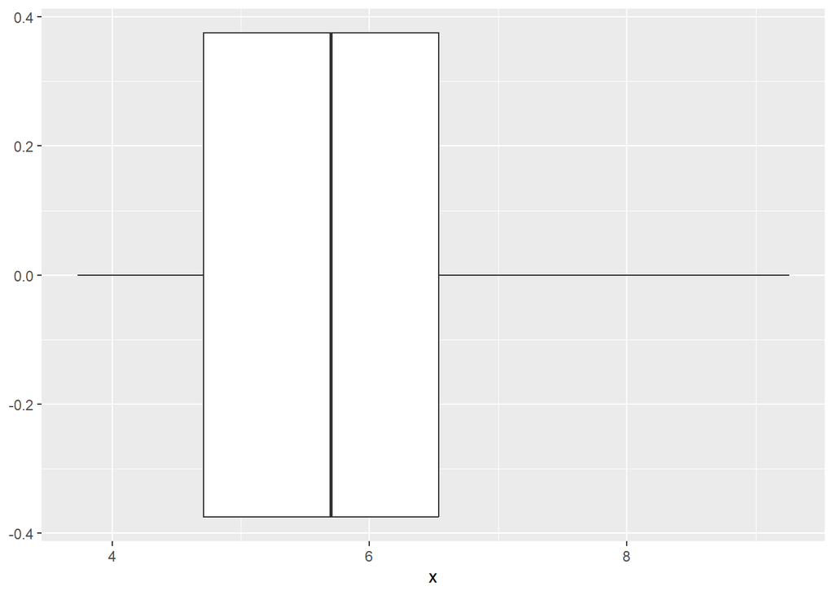

```r
df %>%
  ggplot(aes(x=x)) +
  geom_boxplot()
```

### Boxplot of price after taking the log out of it

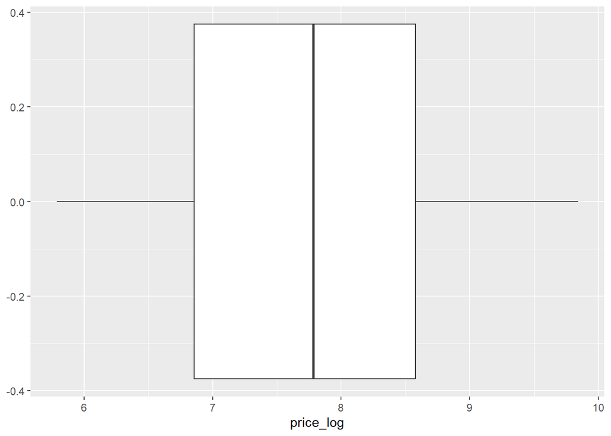

```r
df %>%
  ggplot(aes(x=price_log)) +
  geom_boxplot()
```

```r
df$cut <- factor(df$cut, ordered = FALSE)
df$color <- factor(df$color,ordered = FALSE)
df$clarity <- factor(df$clarity,ordered=FALSE)
```

## Modelling

### Data partition

```r
set.seed(123)
data_partition <- caret::createDataPartition(df$price_log,p=0.7,list=FALSE)

train_set <- df[data_partition,]
test_set <- df[-data_partition,]
```

```r
print(dim(train_set))
```

```
## [1] 37738     5
```

```r
print(dim(test_set))
```

```
## [1] 16170     5
```

```r
print(nrow(train_set)/(nrow(train_set)+nrow(test_set)))
```

```
## [1] 0.7000445
```

### Relationship between x and price_log

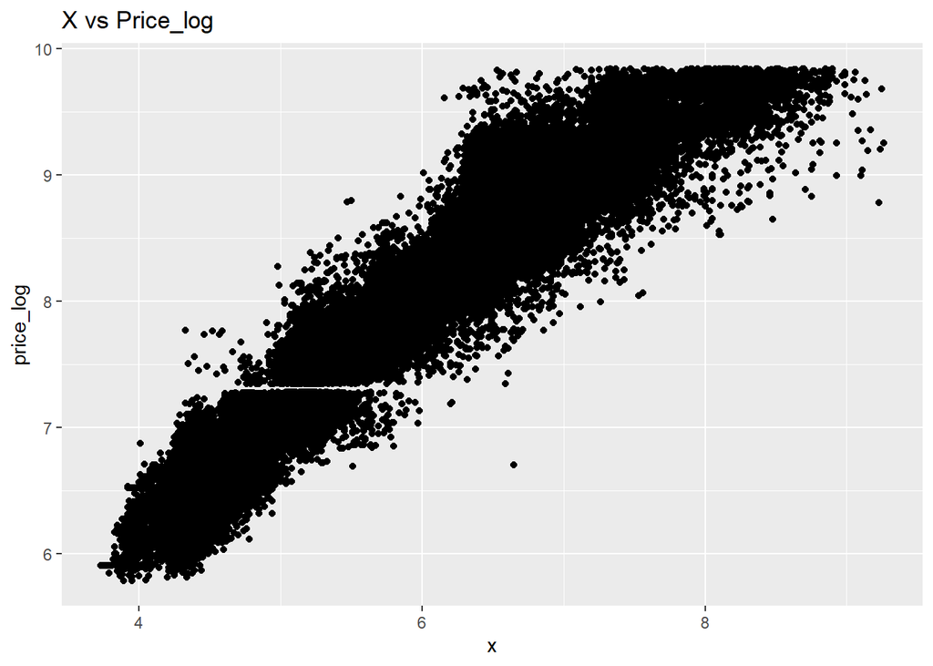

```r
df %>%
  ggplot(aes(x=x,y=price_log)) +
  geom_point() +
  labs(title='X vs Price_log')
```

### Creating train set

```r
train_set <- dummy_cols(train_set,remove_first_dummy = TRUE,remove_selected_columns = TRUE)
```

### Creating test set

```r
test_set <- dummy_cols(test_set,remove_first_dummy = TRUE,remove_selected_columns = TRUE)
```

### Model formula

```r
mod <- lm(formula = price_log ~.,data=train_set)
print(summary(mod))
```

```
##
## Call:
## lm(formula = price_log ~ ., data = train_set)
##
## Residuals:
##      Min       1Q   Median       3Q      Max
## -2.31917 -0.11391  0.01568  0.12430  1.75551
##
## Coefficients:
##                  Estimate Std. Error t value Pr(>|t|)
## (Intercept)      2.464542   0.008331 295.833   <2e-16 ***
## x                0.959602   0.001053 911.303   <2e-16 ***
## `cut_Very Good`  0.037013   0.003747   9.877   <2e-16 ***
## cut_Premium     -0.001616   0.003649  -0.443    0.658
## cut_Ideal        0.059018   0.003478  16.967   <2e-16 ***
## color_E         -0.059940   0.003834 -15.635   <2e-16 ***
## color_F         -0.081540   0.003875 -21.045   <2e-16 ***
## color_G         -0.139853   0.003779 -37.004   <2e-16 ***
## color_H         -0.258103   0.004015 -64.288   <2e-16 ***
## color_I         -0.385741   0.004537 -85.016   <2e-16 ***
## color_J         -0.525986   0.005548 -94.804   <2e-16 ***
## clarity_SI2     -0.309781   0.005558 -55.738   <2e-16 ***
## clarity_SI1     -0.132881   0.005308 -25.034   <2e-16 ***
## clarity_VS2     -0.006980   0.005301  -1.317    0.188
## clarity_VS1      0.056521   0.005497  10.283   <2e-16 ***
## clarity_VVS2     0.160435   0.005906  27.167   <2e-16 ***
## clarity_VVS1     0.212057   0.006293  33.697   <2e-16 ***
## ---
## Signif. codes:  0 '***' 0.001 '**' 0.01 '*' 0.05 '.' 0.1 ' ' 1
##
## Residual standard error: 0.2025 on 37721 degrees of freedom
## Multiple R-squared:  0.9601, Adjusted R-squared:  0.9601
## F-statistic: 5.68e+04 on 16 and 37721 DF,  p-value: < 2.2e-16
```

```r
(exp(coef(mod)["x"]) - 1) * 100 # for every 1 increase in X, price increases by 161%
```

```
##        x
## 161.0656
```

```r
exp(coef(mod))
```

```
##     (Intercept)               x `cut_Very Good`     cut_Premium       cut_Ideal
##      11.7580943       2.6106563       1.0377065       0.9983858       1.0607940
##         color_E         color_F         color_G         color_H         color_I
##       0.9418214       0.9216955       0.8694858       0.7725154       0.6799465
##         color_J     clarity_SI2     clarity_SI1     clarity_VS2     clarity_VS1
##       0.5909722       0.7336078       0.8755695       0.9930447       1.0581490
##    clarity_VVS2    clarity_VVS1
##       1.1740219       1.2362178
```

### Interpretation

1. for every 1 increase in X, price increases by 161%
2. On average, Very Good cut diamonds prices are 1.037 times the reference cut diamonds prices
3. On average, Premium cut diamonds prices are 0.999 times the reference cut diamonds prices
4. On average, Ideal cut diamonds prices are 1.0608 times the reference cut diamonds prices
5. On average, color E diamonds prices are 0.9418 times the reference color diamonds prices
6. On average, color F diamonds prices are 0.9217 times the reference color diamonds prices
7. On average, color G diamonds prices are 0.8695 times the reference color diamonds prices
8. On average, color H diamonds prices are 0.7725 times the reference color diamonds prices
9. On average, color I diamonds prices are 0.6799 times the reference color diamonds prices
10. On average, color J diamonds prices are 0.5910 times the reference color diamonds prices
11. On average, clarity SI2 diamonds prices are 0.7336 times the reference clarity diamonds prices
12. On average, clarity SI1 diamonds prices are 0.8756 times the reference clarity diamonds prices
13. On average, clarity VS2 diamonds prices are 0.9930 times the reference clarity diamonds prices
14. On average, clarity VS1 diamonds prices are 1.058 times the reference clarity diamonds prices
15. On average, clarity VVS2 diamonds prices are 1.174 times the reference clarity diamonds prices
16. On average, clarity VVS1 diamonds prices are 1.2362 times the reference clarity diamonds prices

### Model diagnostics

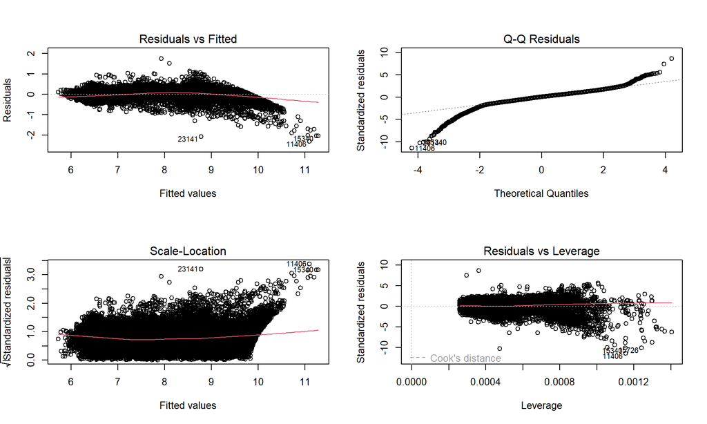

```r
par(mfrow=c(2,2))
plot(mod)
```